# 15 - Taschenrechner

# Einleitung

Deine letzte Übungsaufgabe, dann kann es für dich auch schon richtig losgehen.

# Aufgaben

Für diese Aufgabe gibt es keine Musterlösung und auch keine genaue Erklärung der Aufgaben. Ich erkläre dir lediglich was dein Programm am Ende können soll, stelle also Anforderungen, die dein Programm erfüllen soll. Also viel Spaß beim erarbeiten einer Lösung.

Ziel ist es einen Taschenrechner zu schreiben. Die Oberfläche soll folgendermaßen aussehen:

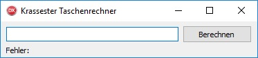

Er soll alle mathematisch korrekten Kombinationen von Zahlen, Klammern, `+`, `-`, `*` und `/` zulassen und berechnen können. Wenn die Syntax der Eingabe falsch ist, soll eine entspechende Fehlermeldung hinter `Fehler` stehen und der `Berechnen`-Button ausgegraut sein:

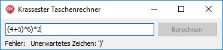

Wenn kein Syntaxfehler auftritt, dann soll der Button klickbar sein:

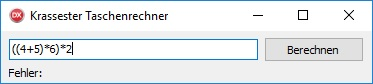

Wenn er nun geklickt wird, gibt es zwei Möglichkeiten.

- Die Eingabe ist mathematisch korrekt und das Ergebnis soll in dem Textfenster angezeigt werden:

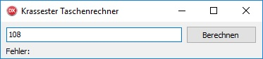

- Die Eingabe ist mathematisch nicht korrekt, der Fehler wird in einem neuen Fenster angezeigt:

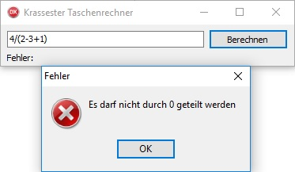

Während der Berechnung soll die Eingabe und der Button disabled sein und der Curser ein Wartekringel sein. Die Oberfläche soll aber trotzdem noch reagiren können.

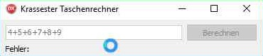

Bei Fragen gerne Fragen.

# Rückblick

Zurück zur Übersicht